# Wizualizacja danych I

26-02-2020

## O mnie

Michał Burdukiewicz:

- bioinformatyk (MiNI PW),
- 12 lat doświadczenia z R,
- Stowarzyszenie Wrocławskich Użytkowników R (stwur.pl),
- Fundacja Why R? (whyr.pl).

Materiały: https://github.com/mini-pw/2020L-WizualizacjaDanych

Mail: michalburdukiewicz@gmail.com

## Literatura

- Wilkinson, L. (2005). The Grammar of Graphics (New York: Springer-Verlag).
- Biecek, P. (2016). Zbiór esejów o sztuce prezentowania danych Odkrywać! Ujawniać! Objaśniać!” (Warszawa: Wydawnictwa Uniwersytetu Warszawskiego.

## Historia wizualizacji danych

## Florence Nightingale

[figure not shown]

## Standardy

[figure not shown]

Joint Committee on Standards for Graphic Presentation (1915). **Standards for Graphic Presentation**. Publications of the American Statistical Association 14, 790–797.

## Gramatyka grafiki

## Gramatyka grafiki

Gramatyka grafiki (grammar of graphics): ustrukturyzowany opis wizualizacji danych.

Wilkinson, L. (2005). The Grammar of Graphics (New York: Springer-Verlag).

## Gramatyka grafiki

[figure not shown]

Źródło: https://blog.gtwang.org/

## Atrybuty wizualne

Atrybuty wizualne (aesthetics): mapowanie danych do osi, kolorów, kształtów.

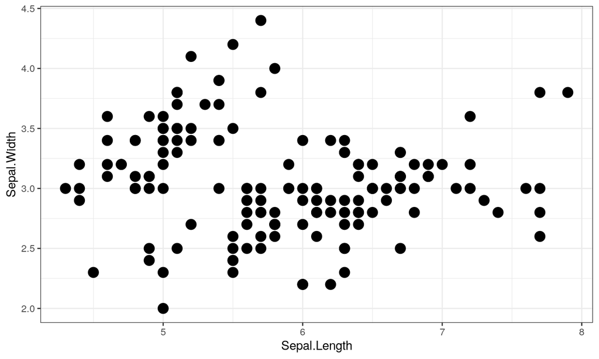

## Atrybuty wizualne

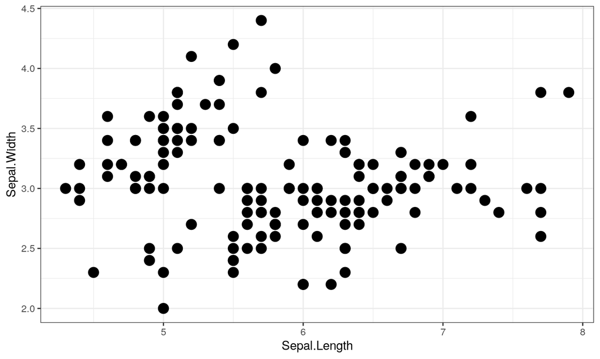

**Oś X:** Sepal.Length. **Oś Y:** Sepal.Width.

## Atrybuty wizualne

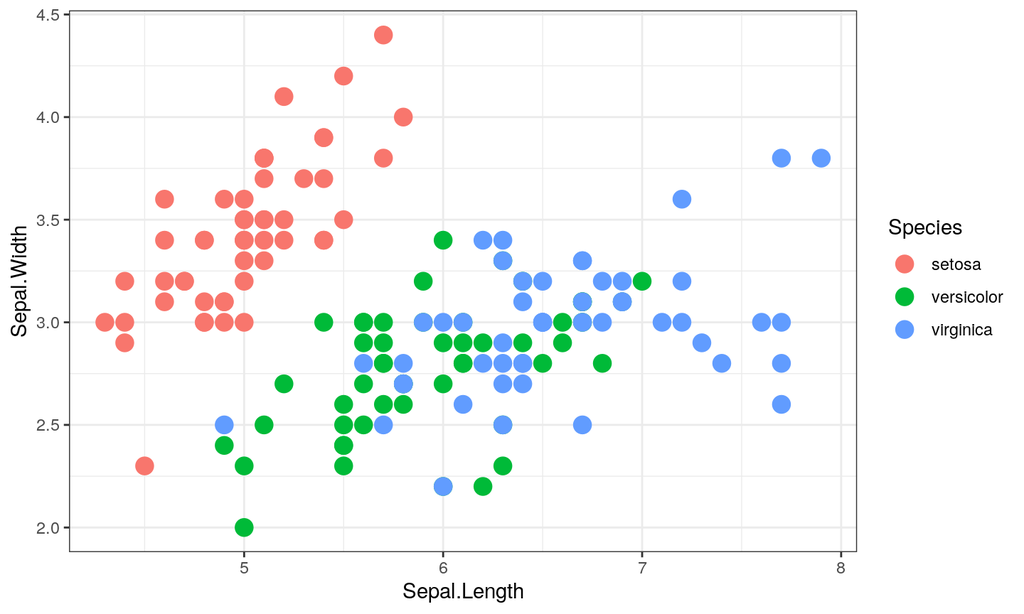

**Oś X:** Sepal.Length. **Oś Y:** Sepal.Width. **Kolor:** Species.

## Atrybuty wizualne

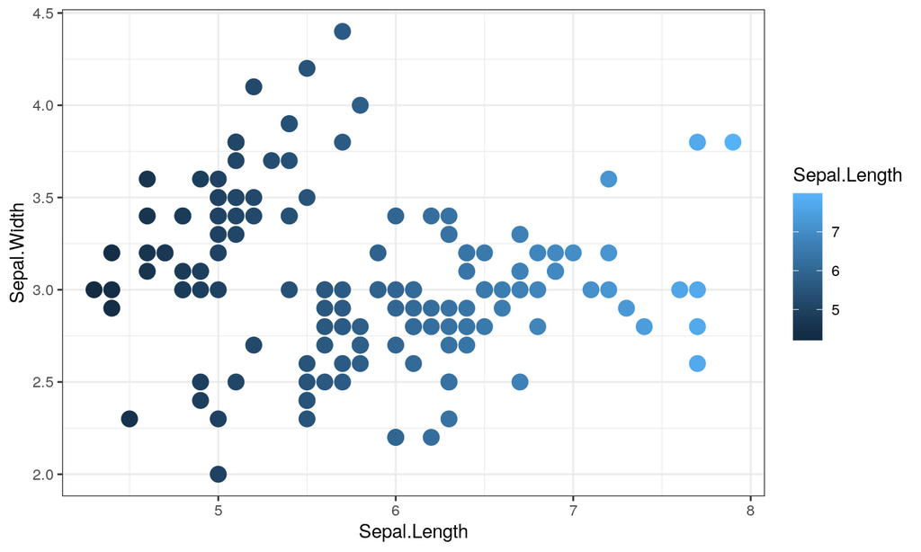

**Oś X:** Sepal.Length. **Oś Y:** Sepal.Width. **Kolor:** Sepal.Length

## Atrybuty wizualne

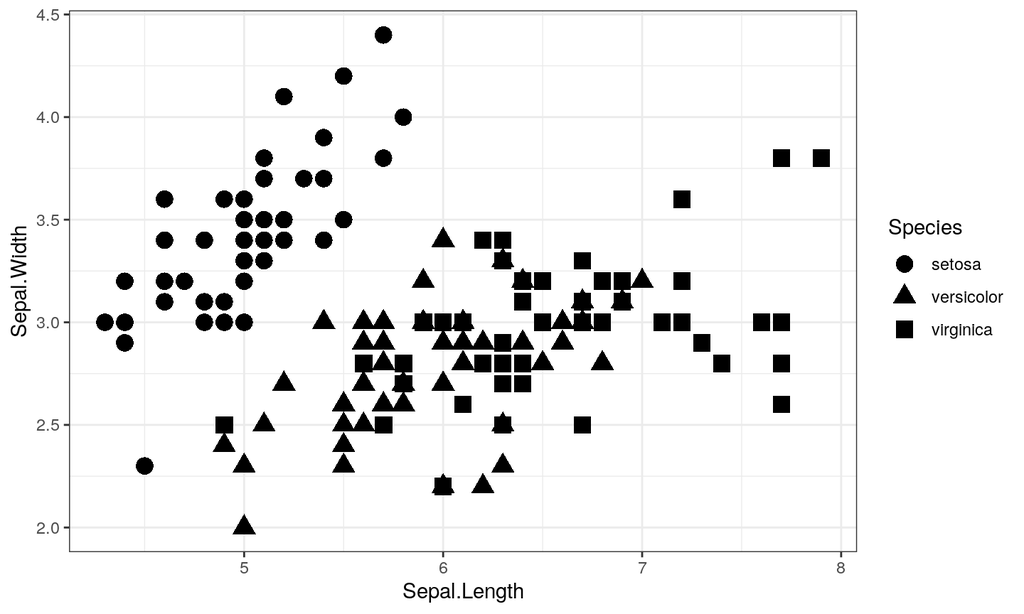

## Geometrie

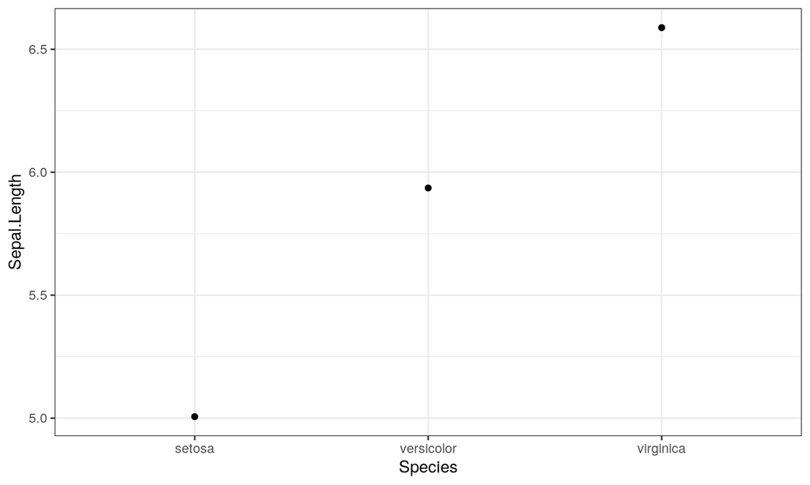

Geometrie: obiekty reprezentujące dane.

## Geometrie

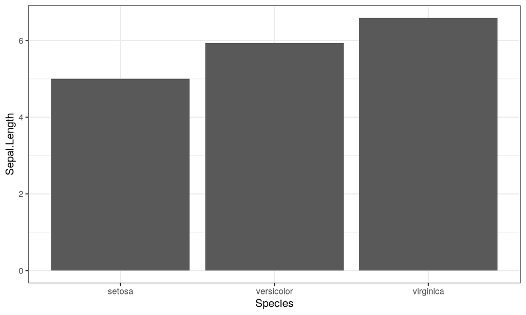

## Geometrie

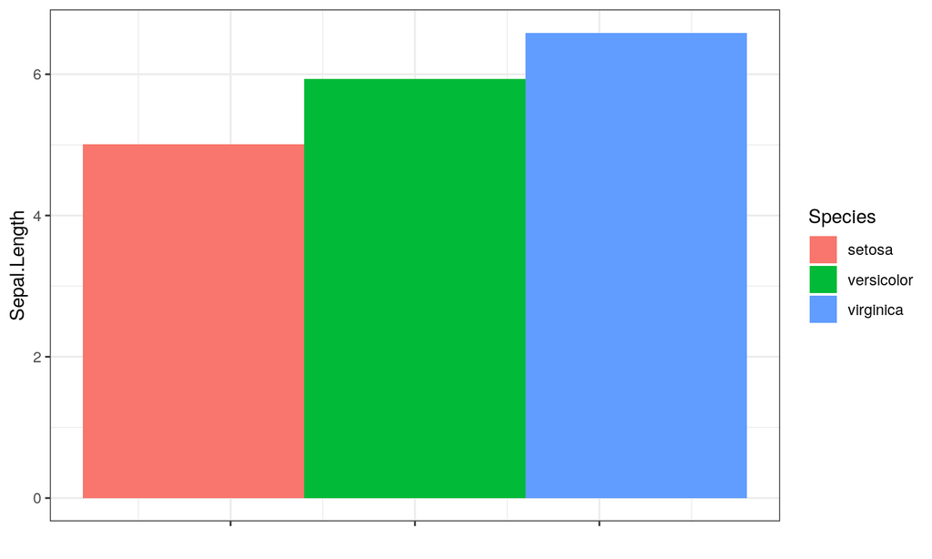

Orientacja obiektów geometrycznych wzgledem siebie też jest istotna.

## Geometrie

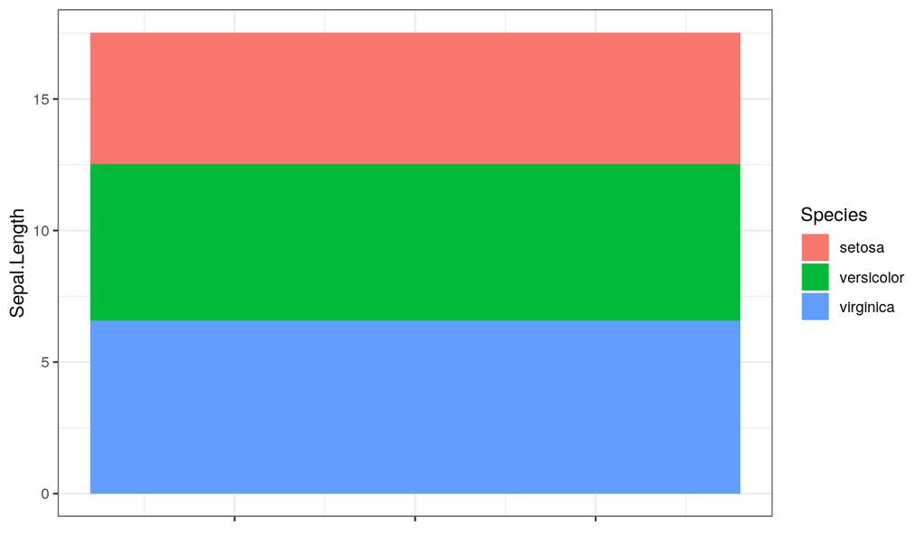

## Fasety

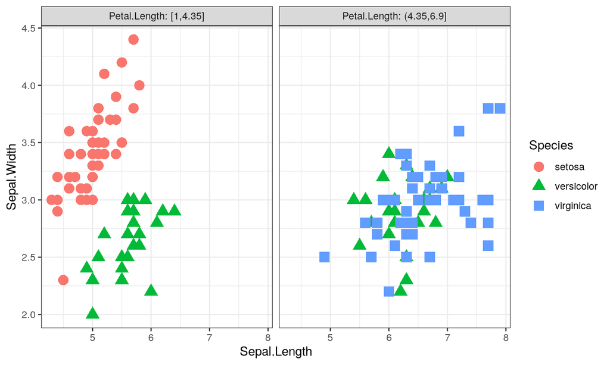

Dzielenie wykresu na podwykresy w zależności od poziomu zmiennej dyskretnej.

## Fasety

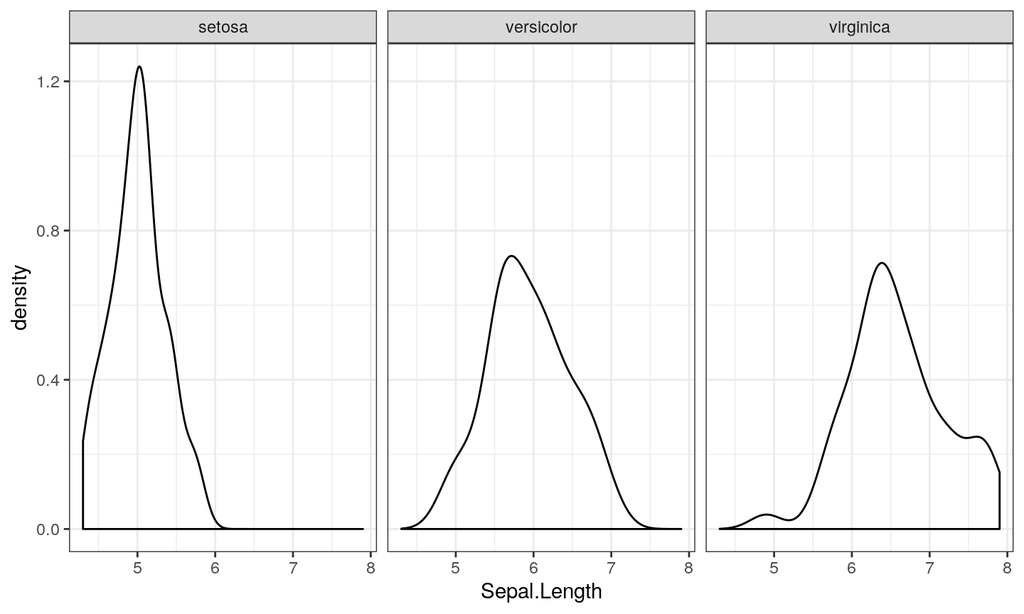

## Statystyki

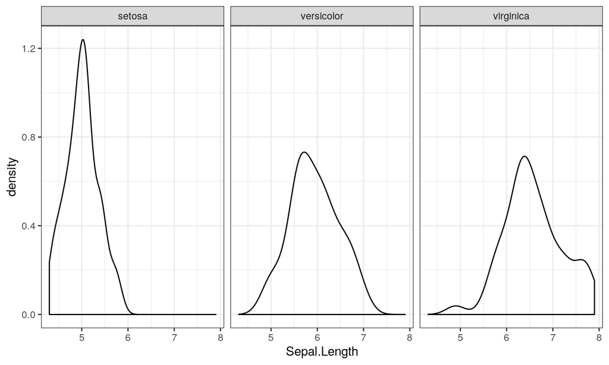

Transformacje danych w celu przypisania ich do atrybutów wizualnych.

## Statystyki

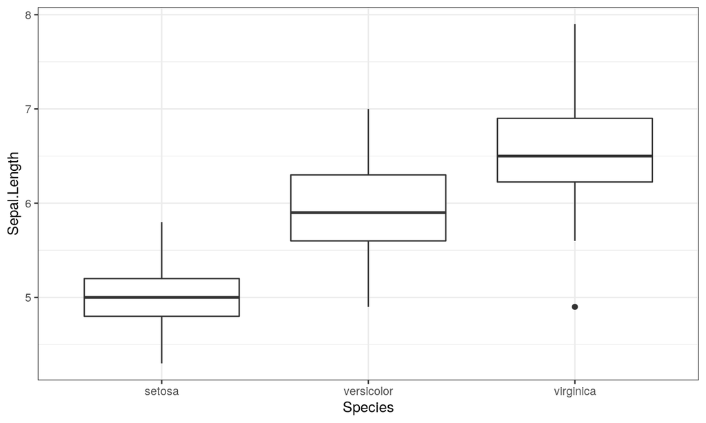

## Statystyki

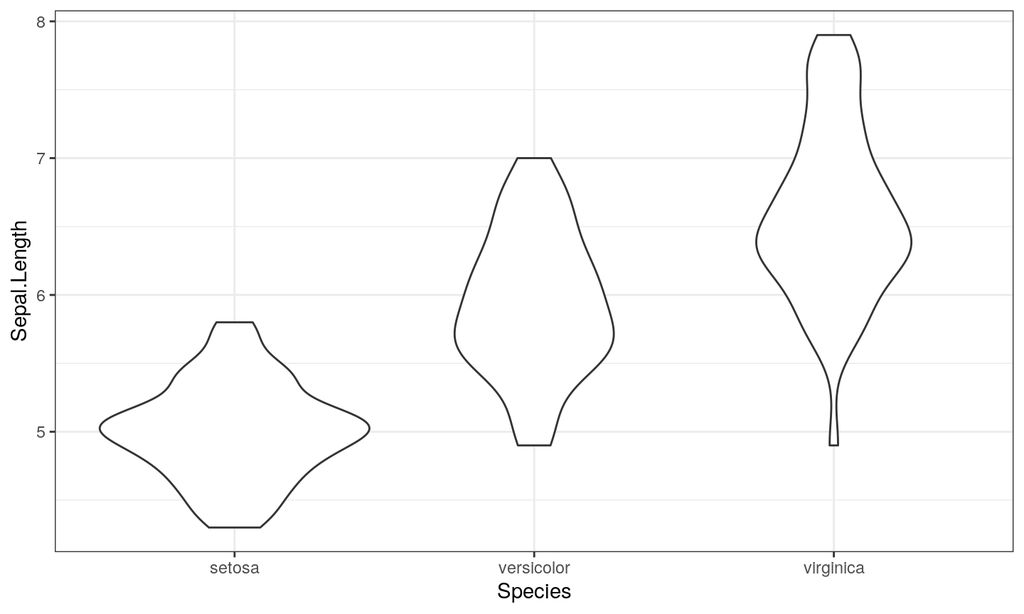

## Statystyki

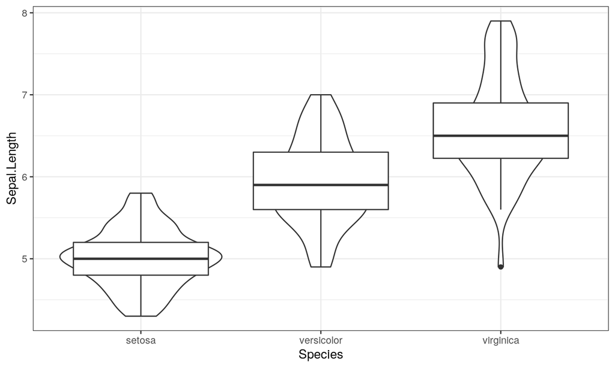

## Statystyki

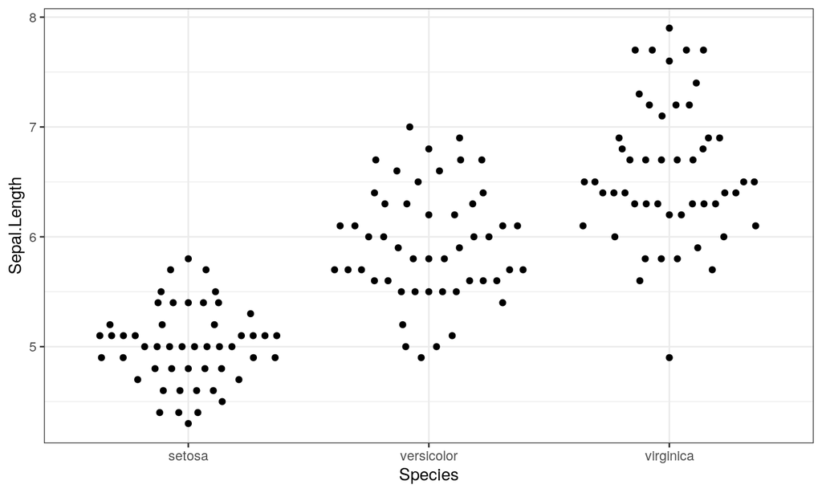

## Statystyki

## Statystyki

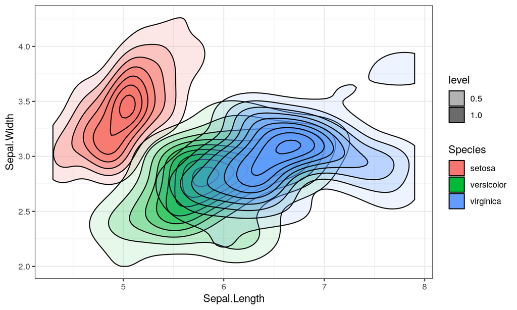

## Koordynaty

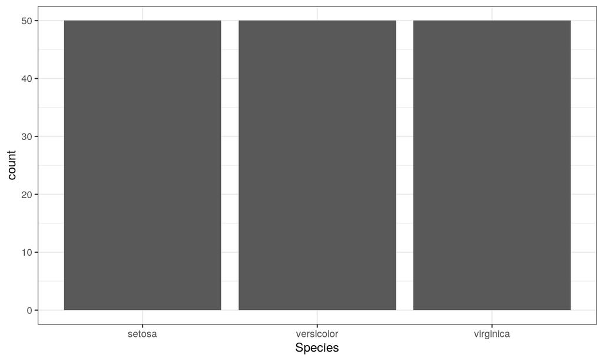

## Koordynaty

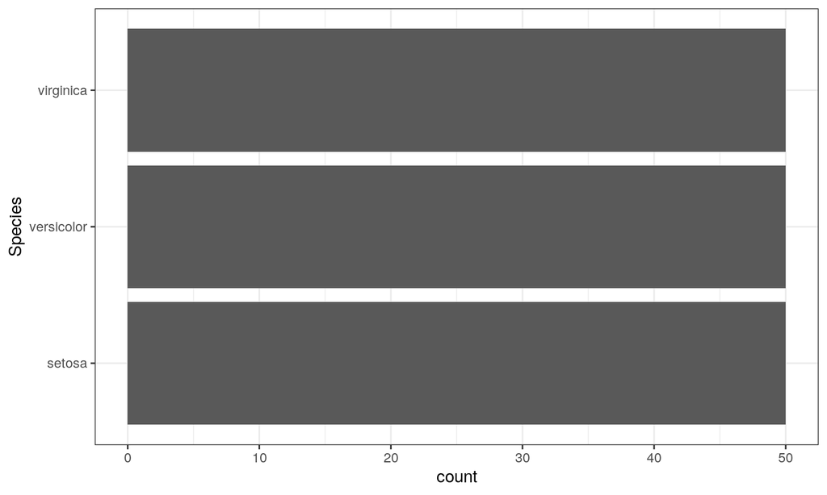

## Koordynaty

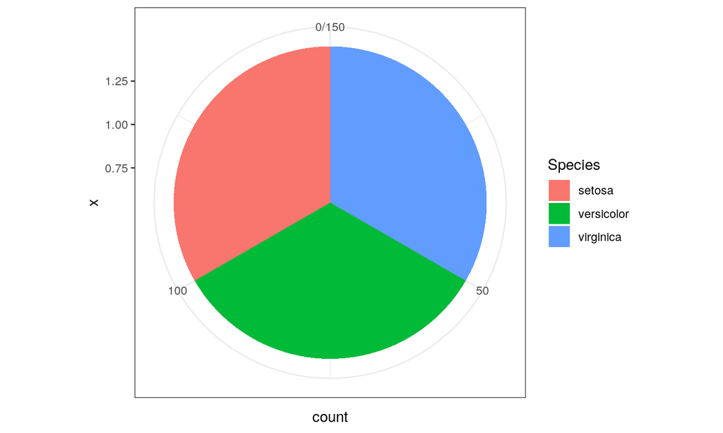

## Motyw

## Motyw

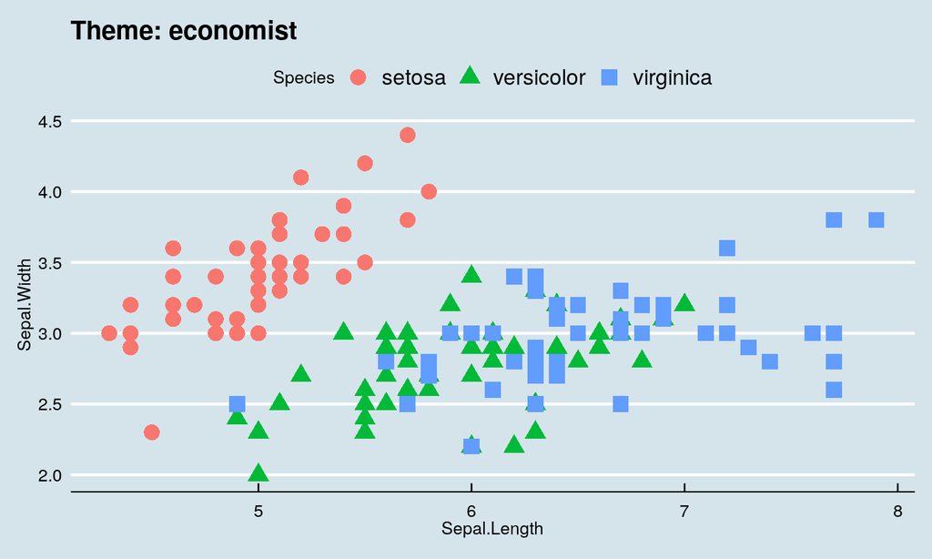

## Motyw

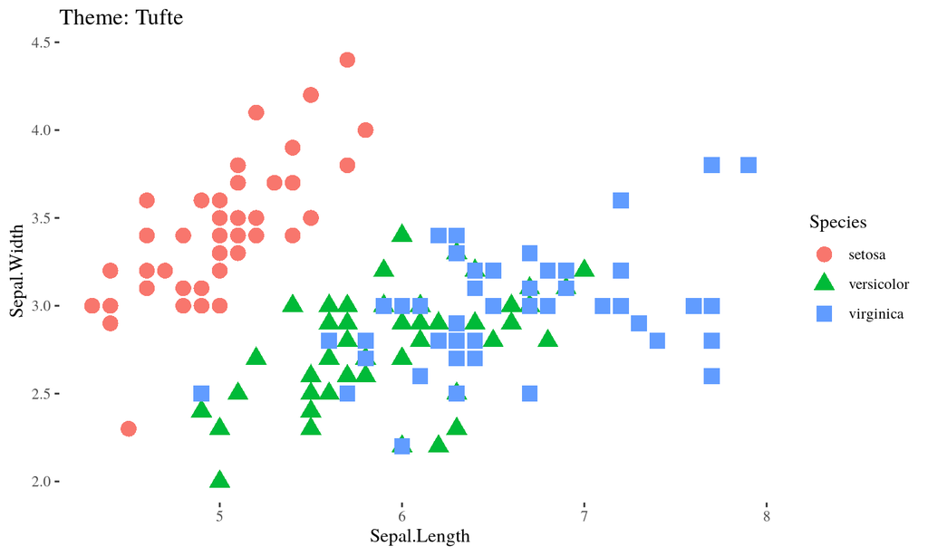

## Motyw

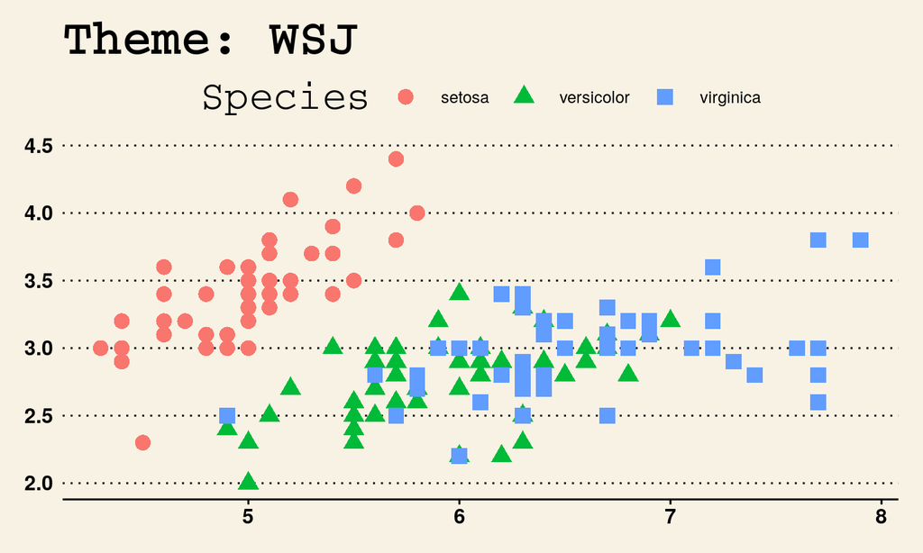

## Motyw

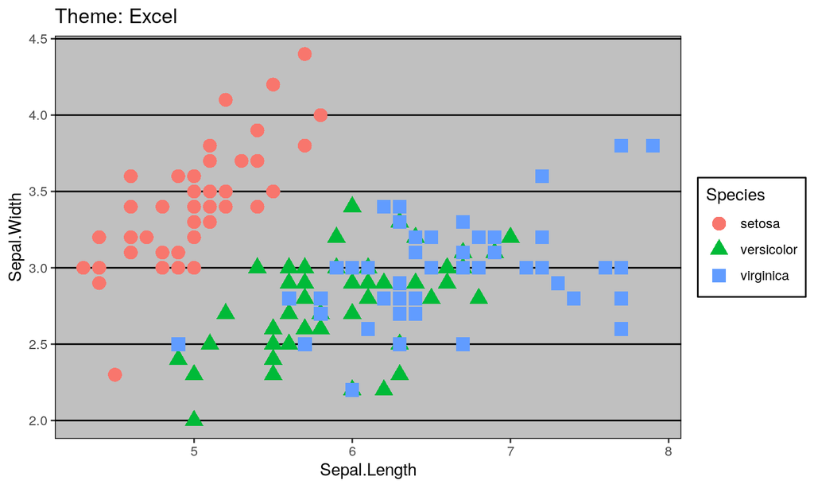

## Gramatyka grafiki

| Nazwa | Przykłady |
| --- | --- |
| Dane (data) |  |
| Atrybuty wizualne (aesthetics) | Osie, kolory, kształty, typy linii |
| Geometrie (geometries) | Linie, słupki, punkty |
| Fasety (facets) | Podrysunki tworzone na podstawie dyskretnych zmiennych |
| Statystyki (statistics) | Średnie, mediany, kwantyle. |
| Koordynaty (coordinates) | Kartezjański, polarny |
| Motyw (theme) | Wygląd rysunku |